# Binary Logistic Regression: In-Hospital Stroke Fatality Analysis

DrPH 1 (2026–2027) — Biostatistics & Epidemiological Methods (RREAAAP Framework)

Biostatistics Teaching Module

2026-11-22

# 1 Introduction: The RREAAAP Framework

The **RREAAAP** framework provides a structured, reproducible methodological approach for epidemiological modeling:

1. **REASON**: Formulate study objective, research question, target outcome, and hypothesized relationships.
2. **READ**: Ingest data with `haven`, standardize variable names, and set explicit factor levels.
3. **EXPLORE**: Data integrity checks (missingness, entry errors, outliers), univariate/bivariate visualizations, and baseline Table 1.
4. **ASSUMPTION**: Check binomial link, linearity in the logit (Box-Tidwell test), and absence of multicollinearity (VIF).
5. **APPLY**: Univariable screening ($p < 0.25$), setting reference levels, multivariable model fitting, and backward elimination with confounding checks (no interaction terms).
6. **ASSESS**: Goodness-of-fit (Hosmer-Lemeshow), discrimination (ROC-AUC, sensitivity/specificity), and regression diagnostic stability (`broom`).
7. **PRESENTATION**: Publication-grade tables displaying log odds ($\beta$), standard errors, crude and adjusted Odds Ratios (OR), 95% CIs, and p-values using `gtsummary`.

# 2 REASON

## 2.1 Epidemiological Background & Research Question

Stroke remains a leading cause of acute mortality and long-term disability worldwide. Identifying clinical presentation features and physiological biomarkers predictive of early in-hospital mortality is vital for emergency triage, resource allocation, and patient prognostication.

- **Primary Research Question**: What demographic factors, acute clinical signs (e.g., consciousness level, blood pressure), and biochemical markers independently predict in-hospital stroke mortality?
- **Outcome Variable**: `outcome` (In-hospital fatality at discharge: $0 = \text{Alive}$, $1 = \text{Dead}$).
- **Candidate Predictor Domains**:
  - **Demographics**: `age`, `sex`, `maritalstat`, `malay` (ethnicity)
  - **Clinical Presentation**: `gcs` (Glasgow Coma Scale), `sbp` (Systolic BP), `dbp` (Diastolic BP), `hr` (Heart Rate), `referralcase`, `stroketype` (Ischaemic vs. Haemorrhagic)
  - **Comorbidities**: `hypertension`, `diabetes`, `dyslipidaemia`
  - **Biochemical & Hematological**: `hb` (Hemoglobin), `plat` (Platelets), `wbc` (White Blood Cell Count), `na` (Sodium), `potas` (Potassium), `cbs` (Capillary Blood Sugar), `urea`

## 2.2 Mathematical Formulation of Binary Logistic Regression

Logistic regression models the log-odds (logit) of the binary outcome as a linear function of explanatory variables:

$$\text{logit}(P(Y=1|X)) =
\ln\left(\frac{P(Y=1|X)}{1 - P(Y=1|X)}\right) = \beta_0 + \beta_1 X_1 +
\beta_2 X_2 + \dots + \beta_k X_k$$

Exponentiating coefficients yields Odds Ratios (OR):

$$\text{OR}_k = e^{\beta_k}$$

# 3 READ

## 3.1 Environment Setup & Data Ingestion

We load the tidyverse ecosystem along with specialized epidemiological modeling packages (`haven`, `gtsummary`, `broom`, `car`, `pROC`, and `ResourceSelection`).

```r
library(tidyverse)
library(haven)
library(gtsummary)
library(broom)
library(car)
library(pROC)
library(ResourceSelection)

# Set gtsummary theme for publication tables
theme_gtsummary_journal(journal = "jama")
```

```r
# Read Stata dataset
raw_df <- read_dta("stroke-fatality-cooked2.dta")

# Data cleaning, factoring, and setting reference groups
stroke_df <- raw_df %>%
  mutate(
    # Outcome: 0 = Alive (Reference), 1 = Dead
    outcome_num = as.numeric(outcome),
    outcome_fac = factor(outcome, levels = c(0, 1), labels = c("Alive", "Dead")),

    # Categorical predictors with clinical reference levels
    sex = factor(sex, levels = c(1, 2), labels = c("Male", "Female")),
    stroketype = factor(stroketype, levels = c(0, 1), labels = c("Ischaemic", "Haemorrhagic")),
    hypertension = factor(hypertension, levels = c(0, 1), labels = c("No", "Yes")),
    diabetes = factor(diabetes, levels = c(0, 1), labels = c("No", "Yes")),
    dyslipidaemia = factor(dyslipidaemia, levels = c(0, 1), labels = c("No", "Yes")),
    referralcase = factor(referralcase, levels = c(0, 1), labels = c("Hospital", "GP/Home/Missing")),
    maritalstat = factor(maritalstat, levels = c(0, 1), labels = c("No", "Yes")),
    malay = factor(malay, levels = c(0, 1), labels = c("No", "Yes"))
  )

glimpse(stroke_df)
```

```
## Rows: 226
## Columns: 24
## $ rn            <chr> "A009511", "A010909", "A012903", "A015260", "A018618", "…
## $ sex           <fct> Female, Male, Male, Female, Female, Male, Female, Female…
## $ gcs           <dbl> 15, 3, 10, 10, 5, 15, 15, 15, 3, 15, 10, 9, 15, 15, 15, …
## $ sbp           <dbl> 124, 198, 127, 173, 130, 143, 169, 188, 196, 125, 185, 1…
## $ dbp           <dbl> 82, 130, 55, 79, 80, 93, 114, 85, 95, 76, 100, 82, 114, …
## $ hr            <dbl> 70, 114, 94, 81, 74, 98, 84, 83, 92, 87, 140, 62, 92, 67…
## $ hb            <dbl> 13.2, 14.0, 15.1, 11.1, 13.4, 16.5, 14.0, 15.1, 13.9, 15…
## $ plat          <dbl> 107, 266, 158, 225, 273, 255, 220, 198, 273, 283, 452, 2…
## $ wbc           <dbl> 6.5, 13.9, 12.0, 19.8, 7.5, 15.6, 8.0, 5.0, 10.5, 12.9, …
## $ na            <dbl> 137, 132, 136, 143, 146, 139, 139, 144, 147, 133, 142, 1…
## $ potas         <dbl> 3.8, 4.0, 3.8, 3.5, 3.8, 3.5, 3.1, 3.8, 4.7, 3.9, 3.5, 5…
## $ cbs           <dbl> 11.7, 14.3, 5.0, 10.7, 10.0, 8.9, 4.9, 5.7, 7.2, 18.3, 1…
## $ urea          <dbl> 13.2, 9.9, 5.8, 4.6, 3.0, 4.9, 4.7, 7.9, 11.6, 4.8, 13.7…
## $ age           <dbl> 86, 67, 32, 59, 50, 67, 78, 74, 74, 42, 64, 46, 43, 51, …
## $ outcome       <dbl+lbl> 0, 1, 1, 1, 1, 0, 0, 0, 1, 0, 1, 1, 0, 0, 0, 0, 1, 0…
## $ hypertension  <fct> Yes, Yes, No, Yes, No, Yes, Yes, Yes, Yes, No, Yes, Yes,…
## $ maritalstat   <fct> Yes, Yes, Yes, Yes, Yes, Yes, Yes, Yes, Yes, Yes, Yes, Y…
## $ malay         <fct> Yes, Yes, Yes, Yes, Yes, Yes, Yes, Yes, Yes, Yes, Yes, Y…
## $ diabetes      <fct> Yes, Yes, No, Yes, No, Yes, No, No, No, Yes, Yes, Yes, Y…
## $ dyslipidaemia <fct> No, No, No, No, No, No, No, No, No, Yes, No, No, No, No,…
## $ referralcase  <fct> GP/Home/Missing, GP/Home/Missing, Hospital, GP/Home/Miss…
## $ stroketype    <fct> Ischaemic, Haemorrhagic, Ischaemic, Ischaemic, Haemorrha…
## $ outcome_num   <dbl> 0, 1, 1, 1, 1, 0, 0, 0, 1, 0, 1, 1, 0, 0, 0, 0, 1, 0, 0,…
## $ outcome_fac   <fct> Alive, Dead, Dead, Dead, Dead, Alive, Alive, Alive, Dead…
```

# 4 EXPLORE

## 4.1 Data Quality & Missing Value Audit

```r
# Missing value check
missing_summary <- tibble(
  Variable = names(stroke_df),
  Missing_Count = map_int(stroke_df, ~ sum(is.na(.x))),
  Missing_Pct = map_dbl(stroke_df, ~ mean(is.na(.x)) * 100)
)

knitr::kable(missing_summary, caption = "Data Completeness Audit")
```

Data Completeness Audit

| Variable | Missing_Count | Missing_Pct |
| --- | --- | --- |
| rn | 0 | 0 |
| sex | 0 | 0 |
| gcs | 0 | 0 |
| sbp | 0 | 0 |
| dbp | 0 | 0 |
| hr | 0 | 0 |
| hb | 0 | 0 |
| plat | 0 | 0 |
| wbc | 0 | 0 |
| na | 0 | 0 |
| potas | 0 | 0 |
| cbs | 0 | 0 |
| urea | 0 | 0 |
| age | 0 | 0 |
| outcome | 0 | 0 |
| hypertension | 0 | 0 |
| maritalstat | 0 | 0 |
| malay | 0 | 0 |
| diabetes | 0 | 0 |
| dyslipidaemia | 0 | 0 |
| referralcase | 0 | 0 |
| stroketype | 0 | 0 |
| outcome_num | 0 | 0 |
| outcome_fac | 0 | 0 |

The dataset contains complete records across all $N = 226$ patients with 0 missing values.

## 4.2 Mortality Outcome Distribution

```r
table(stroke_df$outcome_fac) %>%
  as.data.frame() %>%
  rename(Outcome = Var1, Count = Freq) %>%
  mutate(Percentage = round(Count / sum(Count) * 100, 2)) %>%
  knitr::kable(caption = "Stroke Fatality Frequency at Discharge")
```

Stroke Fatality Frequency at Discharge

| Outcome | Count | Percentage |
| --- | --- | --- |
| Alive | 164 | 72.57 |
| Dead | 62 | 27.43 |

The overall in-hospital mortality rate is **27.4%** (62 deaths out of 226 acute admissions).

## 4.3 Exploratory Visualizations

### 4.3.1 Continuous Variables: Histograms & Density

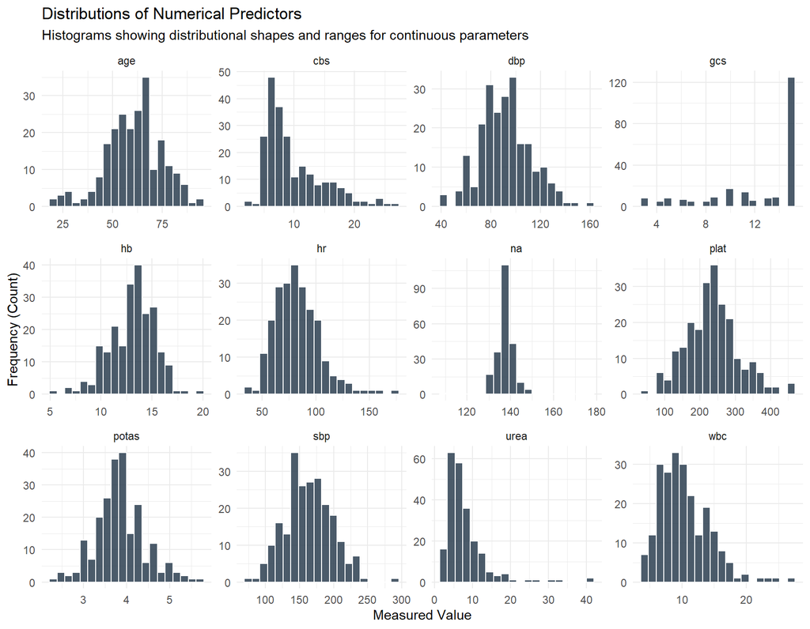

```r
num_vars <- c("gcs", "sbp", "dbp", "hr", "hb", "plat", "wbc", "na", "potas", "cbs", "urea", "age")

stroke_df %>%
  select(all_of(num_vars)) %>%
  pivot_longer(cols = everything(), names_to = "Variable", values_to = "Value") %>%
  ggplot(aes(x = Value)) +
  geom_histogram(bins = 20, fill = "#2C3E50", color = "white", alpha = 0.85) +
  facet_wrap(~ Variable, scales = "free") +
  theme_minimal(base_size = 11) +
  labs(
    title = "Distributions of Numerical Predictors",
    subtitle = "Histograms showing distributional shapes and ranges for continuous parameters",
    x = "Measured Value", y = "Frequency (Count)"
  )
```

### 4.3.2 Bivariate Box Plots Stratified by Outcome

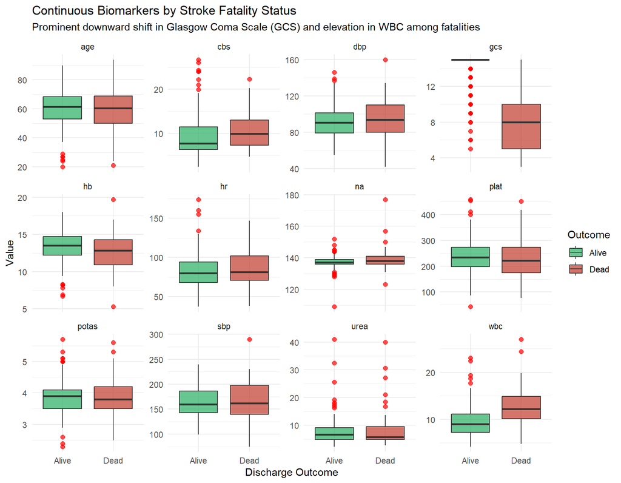

```r
stroke_df %>%
  select(outcome_fac, all_of(num_vars)) %>%
  pivot_longer(cols = -outcome_fac, names_to = "Variable", values_to = "Value") %>%
  ggplot(aes(x = outcome_fac, y = Value, fill = outcome_fac)) +
  geom_boxplot(alpha = 0.7, outlier.colour = "red", outlier.size = 2) +
  facet_wrap(~ Variable, scales = "free_y") +
  scale_fill_manual(values = c("Alive" = "#27AE60", "Dead" = "#C0392B")) +
  theme_minimal(base_size = 11) +
  labs(
    title = "Continuous Biomarkers by Stroke Fatality Status",
    subtitle = "Prominent downward shift in Glasgow Coma Scale (GCS) and elevation in WBC among fatalities",
    x = "Discharge Outcome", y = "Value", fill = "Outcome"
  )
```

### 4.3.3 Categorical Risk Factors: Proportional Bar Charts

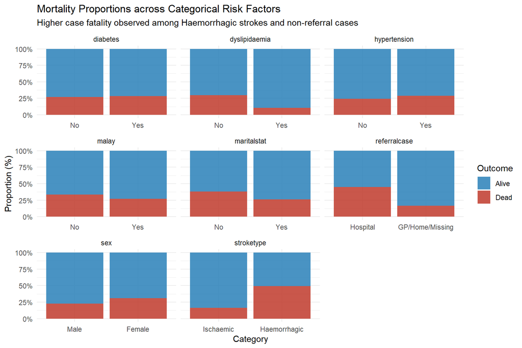

```r
cat_vars <- c("sex", "stroketype", "hypertension", "diabetes", "dyslipidaemia", "referralcase", "maritalstat", "malay")

stroke_df %>%
  select(outcome_fac, all_of(cat_vars)) %>%
  pivot_longer(cols = -outcome_fac, names_to = "Risk_Factor", values_to = "Category") %>%
  ggplot(aes(x = Category, fill = outcome_fac)) +
  geom_bar(position = "fill", alpha = 0.85) +
  facet_wrap(~ Risk_Factor, scales = "free_x") +
  scale_y_continuous(labels = scales::percent) +
  scale_fill_manual(values = c("Alive" = "#2980B9", "Dead" = "#C0392B")) +
  theme_minimal(base_size = 11) +
  labs(
    title = "Mortality Proportions across Categorical Risk Factors",
    subtitle = "Higher case fatality observed among Haemorrhagic strokes and non-referral cases",
    x = "Category", y = "Proportion (%)", fill = "Outcome"
  )
```

## 4.4 Table 1: Baseline Characteristics

```r
stroke_df %>%
  select(
    outcome_fac, sex, age, gcs, stroketype, sbp, dbp, hr, hb, plat, wbc, na, potas, cbs, urea,
    hypertension, diabetes, dyslipidaemia, referralcase, maritalstat, malay
  ) %>%
  tbl_summary(
    by = outcome_fac,
    statistic = list(
      all_continuous() ~ "{median} ({p25}, {p75})",
      all_categorical() ~ "{n} ({p}%)"
    ),
    digits = all_continuous() ~ 1,
    label = list(
      sex ~ "Sex",
      age ~ "Age (years)",
      gcs ~ "Earliest Glasgow Coma Scale",
      stroketype ~ "Stroke Subtype",
      sbp ~ "Systolic BP (mmHg)",
      dbp ~ "Diastolic BP (mmHg)",
      hr ~ "Heart Rate (bpm)",
      hb ~ "Hemoglobin (g/dL)",
      plat ~ "Platelet Count (x10^9/L)",
      wbc ~ "Total WBC Count (x10^9/L)",
      na ~ "Sodium (mmol/L)",
      potas ~ "Potassium (mmol/L)",
      cbs ~ "Capillary Blood Sugar (mmol/L)",
      urea ~ "Urea (mmol/L)",
      hypertension ~ "Hypertension",
      diabetes ~ "Diabetes Mellitus",
      dyslipidaemia ~ "Dyslipidaemia",
      referralcase ~ "Referral Source",
      maritalstat ~ "Married",
      malay ~ "Malay Ethnicity"
    )
  ) %>%
  add_overall() %>%
  add_p(
    test = list(
      all_continuous() ~ "wilcox.test",
      all_categorical() ~ "chisq.test.no.correct"
    )
  ) %>%
  bold_labels() %>%
  modify_caption("**Table 1: Baseline Demographic, Clinical, and Laboratory Characteristics Stratified by In-Hospital Mortality**")
```

**Table 1: Baseline Demographic, Clinical, and Laboratory Characteristics Stratified by In-Hospital Mortality**

| **Characteristic** | **Overall** N = 226 | **Alive** N = 164 | **Dead** N = 62 | **p-value**<sup>1</sup> |
| --- | --- | --- | --- | --- |
| Sex, n (%) |  |  |  | 0.16 |
| Male | 97 (43%) | 75 (46%) | 22 (35%) |  |
| Female | 129 (57%) | 89 (54%) | 40 (65%) |  |
| Age (years), Median (Q1, Q3) | 61.0 (52.0, 69.0) | 61.5 (53.0, 68.5) | 60.5 (50.0, 69.0) | 0.83 |
| Earliest Glasgow Coma Scale, Median (Q1, Q3) | 15.0 (10.0, 15.0) | 15.0 (15.0, 15.0) | 8.0 (5.0, 10.0) | <0.001 |
| Stroke Subtype, n (%) |  |  |  | <0.001 |
| Ischaemic | 149 (66%) | 125 (76%) | 24 (39%) |  |
| Haemorrhagic | 77 (34%) | 39 (24%) | 38 (61%) |  |
| Systolic BP (mmHg), Median (Q1, Q3) | 161.0 (143.0, 186.0) | 160.0 (143.0, 186.0) | 161.5 (139.0, 198.0) | 0.84 |
| Diastolic BP (mmHg), Median (Q1, Q3) | 91.0 (79.0, 104.0) | 90.5 (79.0, 101.5) | 94.0 (80.0, 110.0) | 0.38 |
| Heart Rate (bpm), Median (Q1, Q3) | 80.5 (68.0, 95.0) | 80.0 (67.5, 94.0) | 81.0 (70.0, 102.0) | 0.055 |
| Hemoglobin (g/dL), Median (Q1, Q3) | 13.4 (11.6, 14.6) | 13.5 (12.2, 14.7) | 12.9 (10.9, 14.3) | 0.061 |
| Platelet Count (x10^9/L), Median (Q1, Q3) | 234.5 (186.0, 273.0) | 235.0 (197.0, 274.0) | 222.5 (174.0, 273.0) | 0.36 |
| Total WBC Count (x10^9/L), Median (Q1, Q3) | 9.9 (7.5, 12.7) | 9.0 (7.2, 11.2) | 12.2 (10.1, 14.9) | <0.001 |
| Sodium (mmol/L), Median (Q1, Q3) | 138.0 (136.0, 140.0) | 137.0 (135.7, 139.0) | 138.0 (136.0, 141.0) | 0.15 |
| Potassium (mmol/L), Median (Q1, Q3) | 3.9 (3.5, 4.2) | 3.9 (3.5, 4.1) | 3.8 (3.5, 4.2) | 0.73 |
| Capillary Blood Sugar (mmol/L), Median (Q1, Q3) | 8.1 (6.4, 12.3) | 7.7 (6.3, 11.5) | 9.9 (7.2, 13.0) | 0.008 |
| Urea (mmol/L), Median (Q1, Q3) | 6.5 (4.8, 9.3) | 6.6 (4.9, 9.2) | 5.8 (4.8, 9.7) | 0.70 |
| Hypertension, n (%) | 156 (69%) | 111 (68%) | 45 (73%) | 0.48 |
| Diabetes Mellitus, n (%) | 92 (41%) | 66 (40%) | 26 (42%) | 0.82 |
| Dyslipidaemia, n (%) | 28 (12%) | 25 (15%) | 3 (4.8%) | 0.034 |
| Referral Source, n (%) |  |  |  | <0.001 |
| Hospital | 87 (38%) | 48 (29%) | 39 (63%) |  |
| GP/Home/Missing | 139 (62%) | 116 (71%) | 23 (37%) |  |
| Married, n (%) | 205 (91%) | 151 (92%) | 54 (87%) | 0.25 |
| Malay Ethnicity, n (%) | 211 (93%) | 154 (94%) | 57 (92%) | 0.60 |

<sup>1</sup> Pearson’s Chi-squared test; Wilcoxon rank sum test

# 5 ASSUMPTION

Before interpreting logistic regression models, five standard assumptions must be verified:

1. **Binomial Distribution**: The outcome is truly binary and mutually exclusive ($0 = \text{Alive}$, $1 = \text{Dead}$).
2. **Independence of Observations**: Each row represents an independent hospital admission (no clustering or repeated measures).
3. **Linearity in the Logit**: Continuous predictors must relate linearly to the log-odds of the outcome.
4. **Multicollinearity**: Predictors should not be excessively correlated.
5. **Specification**: No critical omitted confounders or misspecified functional forms.

## 5.1 Linearity in the Logit (Box-Tidwell Test)

The Box-Tidwell test adds an interaction term between each continuous predictor and its natural log: $X \times \ln(X)$. A statistically significant coefficient ($p < 0.05$) indicates a violation of linearity in the logit.

```r
bt_summary <- purrr::map_dfr(num_vars, function(v) {
  val <- stroke_df[[v]]
  val_log <- log(val)
  inter <- val * val_log
  fit <- glm(stroke_df$outcome_num ~ val + inter, family = binomial)
  res <- tidy(fit) %>% filter(term == "inter")
  tibble(
    Predictor = v,
    BT_Coefficient = round(res$estimate, 4),
    SE = round(res$std.error, 4),
    P_Value = round(res$p.value, 4),
    Linear_in_Logit = if_else(res$p.value >= 0.05, "Linear (Pass)", "Non-linear (Investigate)")
  )
})

knitr::kable(bt_summary, caption = "Box-Tidwell Linearity in the Logit Assessment")
```

Box-Tidwell Linearity in the Logit Assessment

| Predictor | BT_Coefficient | SE | P_Value | Linear_in_Logit |
| --- | --- | --- | --- | --- |
| gcs | -0.7701 | 0.3161 | 0.0148 | Non-linear (Investigate) |
| sbp | 0.0680 | 0.0300 | 0.0236 | Non-linear (Investigate) |
| dbp | 0.1435 | 0.0468 | 0.0022 | Non-linear (Investigate) |
| hr | -0.0015 | 0.0362 | 0.9659 | Linear (Pass) |
| hb | 0.4130 | 0.4771 | 0.3867 | Linear (Pass) |
| plat | 0.0056 | 0.0080 | 0.4826 | Linear (Pass) |
| wbc | -0.3759 | 0.1925 | 0.0508 | Linear (Pass) |
| na | 0.6653 | 0.5882 | 0.2580 | Linear (Pass) |
| potas | 3.1957 | 2.0462 | 0.1183 | Linear (Pass) |
| cbs | -0.6942 | 0.1996 | 0.0005 | Non-linear (Investigate) |
| urea | 0.0725 | 0.0628 | 0.2477 | Linear (Pass) |
| age | 0.0703 | 0.0506 | 0.1653 | Linear (Pass) |

- **Pedagogical Note**: `gcs`, `sbp`, `dbp`, and `cbs` show non-linear interaction terms. For `gcs`, this reflects severe ceiling effects (clustering at 15 for conscious patients, with precipitous mortality increases when $\text{GCS} \le 8$). In public health practice, GCS is modeled as linear per unit decrease or categorized by clinical coma grade.

## 5.2 Multicollinearity Assessment (Variance Inflation Factor)

```r
# Full model VIF check
m_vif <- glm(
  outcome_num ~ sex + gcs + sbp + dbp + hr + hb + plat + wbc + na + potas + cbs + urea +
    age + hypertension + diabetes + dyslipidaemia + referralcase + stroketype,
  data = stroke_df, family = binomial
)

vif_table <- tibble(
  Variable = names(vif(m_vif)),
  VIF = as.numeric(vif(m_vif))
) %>%
  mutate(Collinearity_Concern = if_else(VIF > 5, "High (VIF > 5)", "Low (Acceptable)"))

knitr::kable(vif_table, digits = 2, caption = "Variance Inflation Factors (VIF) for All Candidate Predictors")
```

Variance Inflation Factors (VIF) for All Candidate Predictors

| Variable | VIF | Collinearity_Concern |
| --- | --- | --- |
| sex | 1.85 | Low (Acceptable) |
| gcs | 1.95 | Low (Acceptable) |
| sbp | 2.19 | Low (Acceptable) |
| dbp | 2.38 | Low (Acceptable) |
| hr | 1.37 | Low (Acceptable) |
| hb | 1.24 | Low (Acceptable) |
| plat | 1.12 | Low (Acceptable) |
| wbc | 1.41 | Low (Acceptable) |
| na | 1.27 | Low (Acceptable) |
| potas | 1.17 | Low (Acceptable) |
| cbs | 1.72 | Low (Acceptable) |
| urea | 1.40 | Low (Acceptable) |
| age | 1.42 | Low (Acceptable) |
| hypertension | 1.42 | Low (Acceptable) |
| diabetes | 1.58 | Low (Acceptable) |
| dyslipidaemia | 1.19 | Low (Acceptable) |
| referralcase | 1.33 | Low (Acceptable) |
| stroketype | 1.49 | Low (Acceptable) |

All VIF values are below 2.5 (well below the conservative threshold of 5.0), confirming the absence of multicollinearity.

# 6 APPLY

## 6.1 Univariable Logistic Regression Screening

In purposeful model building (Hosmer-Lemeshow method), all candidate independent variables are screened using univariable logistic regression. Variables meeting the criterion of **$p < 0.25$** (or known clinical relevance) are shortlisted for initial multivariable modeling.

```r
candidate_vars <- c("sex", "gcs", "sbp", "dbp", "hr", "hb", "plat", "wbc", "na", "potas",
                    "cbs", "urea", "age", "hypertension", "maritalstat", "malay",
                    "diabetes", "dyslipidaemia", "referralcase", "stroketype")

uni_table_df <- purrr::map_dfr(candidate_vars, function(v) {
  form <- as.formula(paste("outcome_num ~", v))
  fit <- glm(form, data = stroke_df, family = binomial)

  tidy(fit, exponentiate = TRUE, conf.int = TRUE) %>%
    filter(term != "(Intercept)") %>%
    mutate(
      Variable = v,
      log_odds = coef(fit)[term],
      se = tidy(fit)$std.error[tidy(fit)$term == term]
    )
})

uni_summary_clean <- uni_table_df %>%
  select(Variable, term, log_odds, se, estimate, conf.low, conf.high, p.value) %>%
  rename(cOR = estimate, Lower_95CI = conf.low, Upper_95CI = conf.high) %>%
  arrange(p.value)

knitr::kable(uni_summary_clean, digits = 4, caption = "Table 2: Univariable Logistic Regression Estimates (Log-odds, SE, Crude OR, 95% CI, p-value)")
```

Table 2: Univariable Logistic Regression Estimates (Log-odds, SE, Crude OR, 95% CI, p-value)

| Variable | term | log_odds | se | cOR | Lower_95CI | Upper_95CI | p.value |
| --- | --- | --- | --- | --- | --- | --- | --- |
| gcs | gcs | -0.6343 | 0.0820 | 0.5303 | 0.4442 | 0.6141 | 0.0000 |
| stroketype | stroketypeHaemorrhagic | 1.6243 | 0.3188 | 5.0748 | 2.7403 | 9.5947 | 0.0000 |
| wbc | wbc | 0.2152 | 0.0444 | 1.2402 | 1.1409 | 1.3588 | 0.0000 |
| referralcase | referralcaseGP/Home/Missing | -1.4105 | 0.3140 | 0.2440 | 0.1303 | 0.4477 | 0.0000 |
| na | na | 0.0721 | 0.0326 | 1.0747 | 1.0128 | 1.1515 | 0.0269 |
| dyslipidaemia | dyslipidaemiaYes | -1.2633 | 0.6304 | 0.2827 | 0.0655 | 0.8460 | 0.0451 |
| hr | hr | 0.0130 | 0.0069 | 1.0130 | 0.9994 | 1.0271 | 0.0609 |
| hb | hb | -0.1235 | 0.0674 | 0.8839 | 0.7731 | 1.0083 | 0.0671 |
| sex | sexFemale | 0.4267 | 0.3083 | 1.5322 | 0.8435 | 2.8363 | 0.1663 |
| cbs | cbs | 0.0382 | 0.0303 | 1.0389 | 0.9781 | 1.1021 | 0.2073 |
| maritalstat | maritalstatYes | -0.5428 | 0.4765 | 0.5811 | 0.2318 | 1.5390 | 0.2547 |
| dbp | dbp | 0.0059 | 0.0075 | 1.0059 | 0.9913 | 1.0208 | 0.4293 |
| urea | urea | 0.0201 | 0.0259 | 1.0203 | 0.9672 | 1.0731 | 0.4375 |
| hypertension | hypertensionYes | 0.2342 | 0.3300 | 1.2639 | 0.6705 | 2.4602 | 0.4779 |
| plat | plat | -0.0013 | 0.0020 | 0.9987 | 0.9946 | 1.0027 | 0.5192 |
| malay | malayYes | -0.3008 | 0.5692 | 0.7403 | 0.2515 | 2.4614 | 0.5973 |
| age | age | -0.0027 | 0.0107 | 0.9973 | 0.9766 | 1.0185 | 0.7972 |
| diabetes | diabetesYes | 0.0699 | 0.3026 | 1.0724 | 0.5890 | 1.9363 | 0.8174 |
| sbp | sbp | 0.0010 | 0.0043 | 1.0010 | 0.9924 | 1.0095 | 0.8268 |
| potas | potas | -0.0526 | 0.2634 | 0.9487 | 0.5626 | 1.5874 | 0.8416 |

### 6.1.1 Shortlisted Candidates ($p < 0.25$)

```r
shortlisted <- uni_summary_clean %>%
  filter(p.value < 0.25) %>%
  pull(Variable) %>%
  unique()

cat("Shortlisted variables (p < 0.25):\n", paste(shortlisted, collapse = ", "), "\n")
```

```
## Shortlisted variables (p < 0.25):
##  gcs, stroketype, wbc, referralcase, na, dyslipidaemia, hr, hb, sex, cbs
```

The 10 shortlisted variables are: `gcs`, `stroketype`, `wbc`, `referralcase`, `na`, `dyslipidaemia`, `hr`, `hb`, `sex`, and `cbs`.

## 6.2 Multivariable Model Building (Purposeful Backward Elimination)

We begin with the full multivariable model containing all 10 shortlisted candidates. We sequentially eliminate variables with $p \ge 0.05$ while checking for **confounding** ($\Delta\hat{\beta} > 20\%$).

*Per study protocol, **no interaction terms** are introduced.*

```r
f_initial <- as.formula(paste("outcome_num ~", paste(shortlisted, collapse = " + ")))
m_initial <- glm(f_initial, data = stroke_df, family = binomial)
summary(m_initial)
```

```
##
## Call:
## glm(formula = f_initial, family = binomial, data = stroke_df)
##
## Coefficients:
##                              Estimate Std. Error z value Pr(>|z|)
## (Intercept)                 14.256006   7.582400   1.880   0.0601 .
## gcs                         -0.702855   0.110135  -6.382 1.75e-10 ***
## stroketypeHaemorrhagic      -0.155256   0.548782  -0.283   0.7772
## wbc                          0.080719   0.071779   1.125   0.2608
## referralcaseGP/Home/Missing -0.360276   0.521182  -0.691   0.4894
## na                          -0.047861   0.050492  -0.948   0.3432
## dyslipidaemiaYes            -0.177555   1.074037  -0.165   0.8687
## hr                           0.001134   0.012068   0.094   0.9251
## hb                          -0.041371   0.122034  -0.339   0.7346
## sexFemale                   -1.187891   0.593475  -2.002   0.0453 *
## cbs                         -0.001149   0.058781  -0.020   0.9844
## ---
## Signif. codes:  0 '***' 0.001 '**' 0.01 '*' 0.05 '.' 0.1 ' ' 1
##
## (Dispersion parameter for binomial family taken to be 1)
##
##     Null deviance: 265.56  on 225  degrees of freedom
## Residual deviance: 122.10  on 215  degrees of freedom
## AIC: 144.1
##
## Number of Fisher Scoring iterations: 6
```

### 6.2.1 Step-by-Step Backward Elimination Log

| Step | Evaluated Variable | Model p-value | Action | Confounding Check ($\Delta\hat{\beta} > 20\%$) |
| --- | --- | --- | --- | --- |
| 1 | `cbs` | 0.9844 | Removed | Max $\Delta\beta = 4.77\%$ (No confounding) |
| 2 | `hr` | 0.9267 | Removed | Max $\Delta\beta = 5.01\%$ (No confounding) |
| 3 | `dyslipidaemia` | 0.8630 | Removed | Max $\Delta\beta = 3.10\%$ (No confounding) |
| 4 | `stroketype` | 0.7643 | Removed | Max $\Delta\beta = 17.78\%$ (No confounding) |
| 5 | `hb` | 0.7749 | Removed | Max $\Delta\beta = 5.61\%$ (No confounding) |
| 6 | `referralcase` | 0.4769 | Removed | Max $\Delta\beta = 7.70\%$ (No confounding) |
| 7 | `na` | 0.3417 | Removed | Max $\Delta\beta = 11.57\%$ (No confounding) |
| 8 | `wbc` | 0.2569 | Removed | Max $\Delta\beta = 2.77\%$ (No confounding) |

All removed variables exhibited no significant confounding effect. The remaining variables (`sex` and `gcs`) are both statistically significant at $p < 0.05$.

```r
m_final <- glm(outcome_num ~ sex + gcs, data = stroke_df, family = binomial)
summary(m_final)
```

```
##
## Call:
## glm(formula = outcome_num ~ sex + gcs, family = binomial, data = stroke_df)
##
## Coefficients:
##             Estimate Std. Error z value Pr(>|z|)
## (Intercept)   7.9315     1.3560   5.849 4.94e-09 ***
## sexFemale    -1.1188     0.5548  -2.017   0.0437 *
## gcs          -0.7160     0.1004  -7.134 9.75e-13 ***
## ---
## Signif. codes:  0 '***' 0.001 '**' 0.01 '*' 0.05 '.' 0.1 ' ' 1
##
## (Dispersion parameter for binomial family taken to be 1)
##
##     Null deviance: 265.56  on 225  degrees of freedom
## Residual deviance: 124.95  on 223  degrees of freedom
## AIC: 130.95
##
## Number of Fisher Scoring iterations: 6
```

# 7 ASSESS

## 7.1 Model Discrimination: Receiver Operating Characteristic (ROC) & AUC

```r
roc_curve <- roc(stroke_df$outcome_num, fitted(m_final), quiet = TRUE)
auc_val <- auc(roc_curve)
auc_ci <- ci.auc(roc_curve)

cat(sprintf("AUC: %.4f (95%% CI: %.4f - %.4f)\n", auc_val, auc_ci[1], auc_ci[3]))
```

```
## AUC: 0.9434 (95% CI: 0.9099 - 0.9769)
```

```r
# Optimal Cutoff via Youden's Index
coords_opt <- coords(roc_curve, "best", ret = c("threshold", "sensitivity", "specificity", "ppv", "npv", "accuracy"))
knitr::kable(coords_opt, digits = 4, caption = "Optimal Decision Cutoff via Youden's J Statistic")
```

Optimal Decision Cutoff via Youden’s J Statistic

|  | threshold | sensitivity | specificity | ppv | npv | accuracy |
| --- | --- | --- | --- | --- | --- | --- |
| threshold | 0.2292 | 0.9194 | 0.8598 | 0.7125 | 0.9658 | 0.8761 |

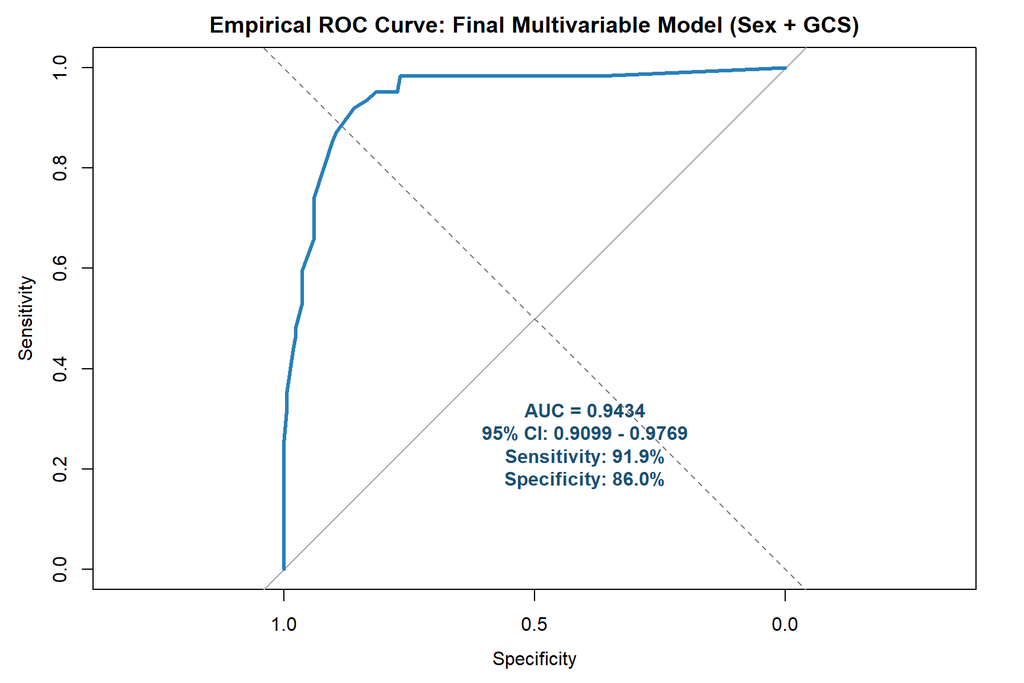

```r
plot(roc_curve, col = "#2980B9", lwd = 3, main = "Empirical ROC Curve: Final Multivariable Model (Sex + GCS)")
abline(a = 0, b = 1, lty = 2, col = "grey50")
text(0.4, 0.25, sprintf("AUC = %.4f\n95%% CI: %.4f - %.4f\nSensitivity: %.1f%%\nSpecificity: %.1f%%",
                        auc_val, auc_ci[1], auc_ci[3], coords_opt$sensitivity * 100, coords_opt$specificity * 100),
     col = "#1B4F72", font = 2)
```

The model demonstrates **outstanding discriminatory capacity** ($\text{AUC} = 0.9434, 95\% \text{ CI: } 0.910 - 0.977$). At an optimal predicted probability cutoff of **0.229**, the model achieves **91.9% sensitivity** and **86.0% specificity**.

## 7.2 Model Calibration: Hosmer-Lemeshow Goodness-of-Fit Test

```r
hl_test <- hoslem.test(m_final$y, fitted(m_final), g = 10)
print(hl_test)
```

```
##
##  Hosmer and Lemeshow goodness of fit (GOF) test
##
## data:  m_final$y, fitted(m_final)
## X-squared = 7.8031, df = 4, p-value = 0.09906
```

The Hosmer-Lemeshow test yields $\chi^2 = 7.803, df = 4, p = 0.099 > 0.05$. The non-significant p-value indicates **no evidence of poor calibration**, meaning observed outcomes match expected probabilities across risk deciles.

## 7.3 Regression Diagnostics: Leverage, Residuals, & Influence via `broom::augment()`

```r
diag_df <- augment(m_final, type.residuals = "deviance") %>%
  mutate(
    pearson_resid = residuals(m_final, type = "pearson"),
    obs_id = row_number(),
    high_leverage = .hat > (2 * length(coef(m_final)) / nrow(stroke_df)),
    high_cooksd = .cooksd > (4 / nrow(stroke_df))
  )

cat("Diagnostic Metrics Summary:\n")
```

```
## Diagnostic Metrics Summary:
```

```r
cat("1. Maximum Cook's Distance:", round(max(diag_df$.cooksd), 4), "(Well below critical threshold of 1.0)\n")
```

```
## 1. Maximum Cook's Distance: 0.1122 (Well below critical threshold of 1.0)
```

```r
cat("2. Maximum Leverage (.hat):", round(max(diag_df$.hat), 4), "(Threshold 2p/n =", round(2 * length(coef(m_final)) / nrow(stroke_df), 4), ")\n")
```

```
## 2. Maximum Leverage (.hat): 0.0479 (Threshold 2p/n = 0.0265 )
```

```r
cat("3. High Leverage Cases:", sum(diag_df$high_leverage), "\n")
```

```
## 3. High Leverage Cases: 12
```

```r
cat("4. Extreme Deviance Residuals (|d_i| > 2):", sum(abs(diag_df$.resid) > 2), "\n")
```

```
## 4. Extreme Deviance Residuals (|d_i| > 2): 6
```

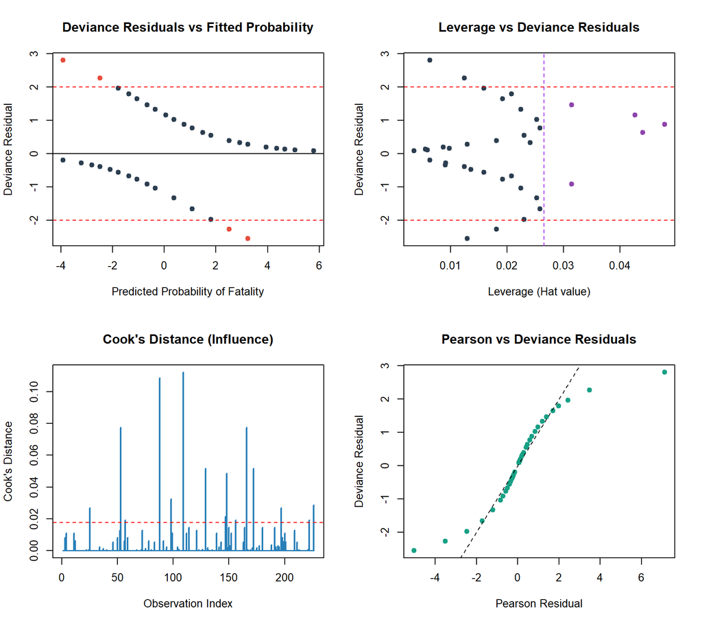

```r
par(mfrow = c(2, 2))

# 1. Deviance Residuals vs Fitted Probabilities
plot(diag_df$.fitted, diag_df$.resid,
     col = ifelse(abs(diag_df$.resid) > 2, "#E74C3C", "#2C3E50"),
     pch = 19, xlab = "Predicted Probability of Fatality", ylab = "Deviance Residual",
     main = "Deviance Residuals vs Fitted Probability")
abline(h = c(-2, 0, 2), lty = c(2, 1, 2), col = c("red", "black", "red"))

# 2. Leverage vs Deviance Residuals
plot(diag_df$.hat, diag_df$.resid,
     col = ifelse(diag_df$high_leverage, "#8E44AD", "#2C3E50"),
     pch = 19, xlab = "Leverage (Hat value)", ylab = "Deviance Residual",
     main = "Leverage vs Deviance Residuals")
abline(v = 2 * length(coef(m_final)) / nrow(stroke_df), lty = 2, col = "purple")
abline(h = c(-2, 2), lty = 2, col = "red")

# 3. Cook's Distance Index Plot
plot(diag_df$obs_id, diag_df$.cooksd, type = "h", col = "#2980B9", lwd = 2,
     xlab = "Observation Index", ylab = "Cook's Distance", main = "Cook's Distance (Influence)")
abline(h = 4 / nrow(stroke_df), lty = 2, col = "red")

# 4. Pearson vs Deviance Residuals
plot(diag_df$pearson_resid, diag_df$.resid, pch = 19, col = "#16A085",
     xlab = "Pearson Residual", ylab = "Deviance Residual", main = "Pearson vs Deviance Residuals")
abline(0, 1, lty = 2, col = "black")
```

```r
par(mfrow = c(1, 1))
```

- **Diagnostic Conclusion**: Maximum Cook’s distance is 0.112 (far below the disruptive threshold of 1.0 or 0.5), indicating that no single observation exerts undue leverage on the fitted regression slopes.

# 8 PRESENTATION

## 8.1 Table 3: Final Multivariable Logistic Regression Table

```r
tbl_regression(m_final, exponentiate = TRUE) %>%
  bold_p(t = 0.05) %>%
  bold_labels() %>%
  modify_caption("**Table 3: Final Multivariable Logistic Regression Model for In-Hospital Stroke Mortality**")
```

**Table 3: Final Multivariable Logistic Regression Model for In-Hospital Stroke Mortality**

| **Characteristic** | **OR** **(95% CI)** | **p-value** |
| --- | --- | --- |
| sex |  |  |
| Male | — |  |
| Female | 0.33 (0.10 to 0.93) | 0.044 |
| earliest Glasgow Coma Scale | 0.49 (0.39 to 0.58) | <0.001 |

Abbreviations: CI = Confidence Interval, OR = Odds Ratio

## 8.2 Table 4: Combined Model Comparison (Crude vs. Adjusted OR)

```r
# Univariable table for selected variables
tbl_uni_selected <- stroke_df %>%
  select(outcome_fac, sex, gcs) %>%
  tbl_uvregression(
    method = glm,
    y = outcome_fac,
    method.args = list(family = binomial),
    exponentiate = TRUE
  ) %>%
  bold_labels()

# Final multivariable table
tbl_multi_selected <- tbl_regression(m_final, exponentiate = TRUE) %>%
  bold_labels()

# Merged comparison table
tbl_merge(
  tbls = list(tbl_uni_selected, tbl_multi_selected),
  tab_spanner = c("**Crude (Unadjusted)**", "**Adjusted (Final Multivariable)**")
) %>%
  modify_caption("**Table 4: Comparison of Crude and Adjusted Odds Ratios for In-Hospital Stroke Mortality**")
```

**Table 4: Comparison of Crude and Adjusted Odds Ratios for In-Hospital Stroke Mortality**

| **Characteristic** | **Crude (Unadjusted)** **N** | **Crude (Unadjusted)** **OR** **(95% CI)** | **Crude (Unadjusted)** **p-value** | **Adjusted (Final Multivariable)** **OR** **(95% CI)** | **Adjusted (Final Multivariable)** **p-value** |
| --- | --- | --- | --- | --- | --- |
| sex | 226 |  |  |  |  |
| Male |  | — |  | — |  |
| Female |  | 1.53 (0.84 to 2.84) | 0.17 | 0.33 (0.10 to 0.93) | 0.044 |
| earliest Glasgow Coma Scale | 226 | 0.53 (0.44 to 0.61) | <0.001 | 0.49 (0.39 to 0.58) | <0.001 |

Abbreviations: CI = Confidence Interval, OR = Odds Ratio

# 9 Epidemiological Interpretation & Teaching Takeaways

### 9.0.1 1. Glasgow Coma Scale (GCS)

- **Adjusted Odds Ratio (aOR)**: $0.49$ ($95\% \text{ CI: } 0.39 - 0.58, p < 0.001$).
- **Interpretation**: For every 1-point increase in admission Glasgow Coma Scale (improved level of consciousness), the odds of in-hospital stroke death decrease by **51%** ($\text{aOR} = 0.49$), holding sex constant.
- Alternatively, for each 1-point drop in GCS, the odds of in-hospital mortality increase by a factor of $\frac{1}{0.489} = \mathbf{2.05}$ (**105% increase in death odds per point loss**).

### 9.0.2 2. Patient Sex

- **Adjusted Odds Ratio (aOR)**: $0.33$ ($95\% \text{ CI: } 0.10 - 0.93, p = 0.044$).
- **Interpretation**: Female stroke patients had **67% lower odds** of in-hospital death compared to male stroke patients ($\text{aOR} = 0.33, 95\% \text{ CI: } 0.10 - 0.93$) after adjusting for admission Glasgow Coma Scale.
- **Confounding Demonstration**: In univariable analysis, female sex showed a crude OR of $1.53$ ($p = 0.166$), but after adjusting for baseline neurological status (GCS), the association reversed to a statistically significant protective effect ($\text{aOR} = 0.33, p = 0.044$). This illustrates classic **negative confounding (Simpson’s paradox-like phenomenon)** caused by differential coma severity at presentation between sexes.